# Supplementary code for ``What Do We Learn from an Equivalence Study Without Statistical Power?’’

Kyle Peyton and Rachel Solnick[^1]

First, let’s reproduce the main result in Linden et al. (2017), hereafter LEA, as reported in Table 2,

```r
# Reproduce main result from study:
n_trt <- 102
n_ctrl <- 100
trt <- c(rep(1, 20), rep(0, n_trt-20))
ctrl <- c(rep(1, 22), rep(0, n_ctrl-22))

s <- sqrt(((n_trt - 1)*var(trt) + (n_ctrl-1)*var(ctrl))/(n_trt + n_ctrl - 2))
se_diff <- s*sqrt(1/n_trt + 1/n_ctrl)

dim <- mean(trt) - mean(ctrl)
c(dim-1.645*se_diff, dim+1.645*se_diff)
```

```
## [1] -0.11829435  0.07045121
```

Next, let’s define a helper function that assigns treatment and computes the 90% confidence interval for the difference in means estimator.

```r
# Helper function for simulations
ci_fun <- function(N = 200, m = NULL, Y1 = NULL, Y0 = NULL, simple = TRUE,
                   truncate = FALSE, cutpoint = NULL){
  # Do a random assignment
  if(simple == FALSE){
    require(randomizr)
    Z <- complete_ra(N = N, m = m)
  } else{
    Z <- rbinom(n = N, size = 1, prob = 1/2)
  }

  # Diff in means for observed data
  Y <- Y1*Z + Y0*(1-Z)

  if(truncate == TRUE){
    Y <- ifelse(Y >= cutpoint, 1, 0)
  }

  fit <- lm(Y ~ Z)
  c(fit$coefficients[2], confint(fit, level = 0.90)[2,])
}
```

The helper functions allows for LEA’s estimation strategy of truncating the outcome variable for patients with more than 1 adverse event via the `truncate` argument in the helper function above. We do not believe this is good practice for an equivalence study since it generates estimates that are attenuated toward zero.

Let’s set up the simulations to estimate the power of LEA’s study under a scenario where the null hypothesis is false so that the pelvic exam and omitting the pelvic exam are indeed equivalent. Let $R = 10,000$ denote the number of repetitions and $\delta = 0.08$ denote the equivalence margin.

```r
R <- 10000
delta <- 0.08

# Adverse event rate is 0.15 in control, and there is no effect of witholding
#   the pelvic exam (treatment):
N <- 720
Y0 <- rpois(n = N, lambda = 0.15)
Y1 <- Y0
```

Let $Z_i$ denote the binary treatment assigment indicator so that $m$ units are treated and $N-m$ units are in control. The estimator here is the simple difference in means, $\hat{\tau}_{DM} = \frac{1}{m}\sum_{i=1}^mY_i\cdot Z_i - \frac{1}{N-m}\sum_{i=m+1}^{N-m}Y_i \cdot (1-Z_i)$. The null hypothesis (non-equivalence) is then $H_0: | \hat{\tau}_{DM}| > \delta$ and the alternative hypothesis (equivalence) is $H_A: |\hat{\tau}_{DM}| < \delta$. The power of this test is

$$\begin{aligned}
1- \text{Pr}(Type \ II \ Error) & = 1 - \text{Pr}(fail \ to \ reject \ H_0 \ | \ H_0 \ is \ false) \\
& = \text{Pr}(reject \ H_0 \ | \ H_0 \ false) \\
& = \text{Pr}\left(declare \ | \hat{\tau}_{DM}| < \delta \ \big| \ |\hat{\tau}_{DM}| < \delta\right) \\
\end{aligned}$$

The TOST procedure used by LEA rejects if and only if the lower bound of the 90% confidence interval is inside the equivalence range, $LB(\hat{\tau}_{DM}) > -\delta$, **and** the upper bound is also inside the range, $UB(\hat{\tau}_{DM}) < \delta$. Failing to reject the null of non-equivalence (because the 90% interval is not bounded by $\pm \ \delta$) is a Type II error when the null is actually false. To estimate the power of this test, we simulate 10,000 intervals under LEA’s design. Let’s start with the idealized version:

```r
# Simulate equivalence intervals when null is false (equivalence true) under
#   ideal design with ~ .80 power.
sim_cis_ideal <- t(replicate(R, ci_fun(N = N, Y1 = Y1, Y0 = Y0,
                                       truncate = TRUE, cutpoint = 1)))

# Confirm power is >= 0.83
sum(sim_cis_ideal[,2] > -delta & sim_cis_ideal[,3] < delta)/R
```

```
## [1] 0.8385
```

As expected, the idealized version is well powered. When the null is actually false (as specified above) the test correctly rejects about 84% of the time. The code below performs the same exercise for the implemented version of LEA’s experiment under charitable assumptions that ignore potential problems due to the application of exclusion rules, treatment non-compliance, and attrition.

```r
# Now simulate equivalence intervals under design actually implemented.
#   Be generous and assume nobody lost to followup.
#   Assume rate is still 0.15 after patients are excluded, etc.
n <- 221
Y0 <- rpois(n = n, lambda = 0.15)
Y1 <- Y0

sim_cis_real <- t(replicate(R, ci_fun(N = n, Y1 = Y1, Y0 = Y0,
                                      truncate = TRUE, cutpoint = 1)))

# What's the power of this design?
sum(sim_cis_real[,2] > -delta & sim_cis_real[,3] < delta)/R
```

```
## [1] 0
```

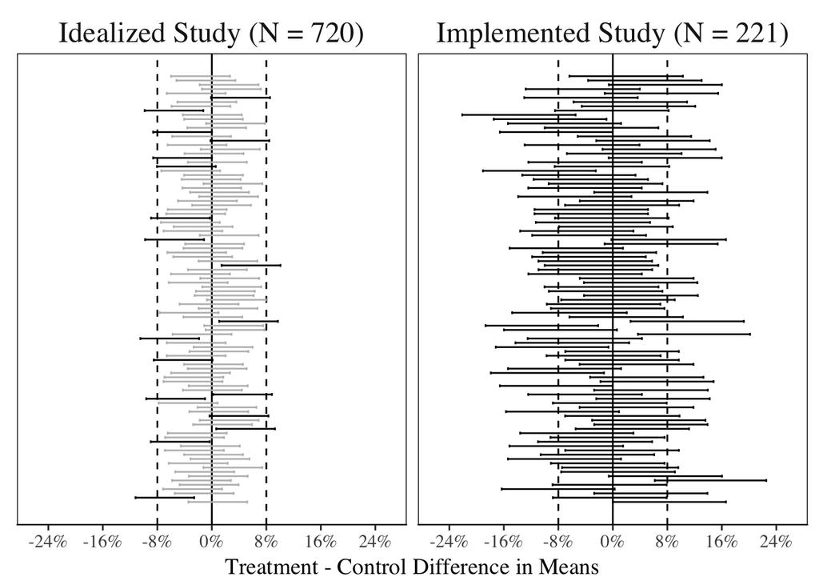

```r
# Take random sample of 100 CIs from each scenario and plot.
sim_cis_null <- rbind(sim_cis_ideal[sample(1:R, 100),],
                      sim_cis_real[sample(1:R, 100),])

# Plot random sample of 100 CIs when the null is false
sim_df_null <- data.frame(dhat = sim_cis_null[, 1], L = sim_cis_null[ ,2],
                          U = sim_cis_null[ ,3],
                          type = c(rep("Idealized Study (N = 720)", 100),
                                   rep("Implemented Study (N = 221)", 100)))

# Flag CIs that would lead to rejection of non-equivalence null, this is
#   the correct choice in this setting. Failing to reject null of
#   non-equivalence is a type 2 error in this setting
index <- which(sim_df_null$L > -delta & sim_df_null$U < delta)

sim_df_null$error <- TRUE
sim_df_null[index,]$error <- FALSE

equiv_plot_null <-
  ggplot(sim_df_null, aes(x = rep(1:100, 2), y = dhat)) +
  geom_hline(yintercept = 0, col = "black", lty = 1, size = 0.5) +
  geom_hline(yintercept = 0.08, col = "black", lty = 2, size = 0.5) +
  geom_hline(yintercept = -0.08, col = "black", lty = 2, size = 0.5) +
  geom_errorbar(aes(ymax = U, ymin = L, color = error), width = 0.65,
                size = 0.5) +
  scale_color_manual(name = "", values = c("grey", "black")) +
  facet_wrap( ~ type) +
  xlab("") + ylab("") +
  scale_y_continuous(name = "Treatment - Control Difference in Means",
                     labels = percent_format(), limits = c(-.26,.26),
                     breaks = c(-0.24, -0.16, -0.08, 0, 0.16, 0.08, 0.24)) +
  coord_flip() +
  theme_tufte(base_size = 14) +
  theme(legend.position="none",
        axis.title.y=element_blank(),
        axis.text.y=element_blank(),
        axis.ticks.y=element_blank(),
        strip.text.x = element_text(size = 18),
        axis.line.x = element_line(color="black"),
        panel.border = element_rect(colour = "black", fill=NA))
equiv_plot_null
```

[^1]: Peyton: kyle.peyton@yale.edu. Solnick: rachel.solnick@yale.edu.